# R Notebook

# DDG2P: The relation between the number of phenotypes and DDD categories of mutation consequences

## 1. Load DDG2P dataset

## 2. Visualization

|  | gene.symbol | gene.mim | disease.name | disease.mim | DDD.category | allelic.requirement | mutation.consequence | phenotypes | organ.specificity.list | pmids | panel | prev.symbols | hgnc.id | gene.disease.pair.entry.date | pLI | pRec | pNull |
| --- | --- | --- | --- | --- | --- | --- | --- | --- | --- | --- | --- | --- | --- | --- | --- | --- | --- |
| 1 | AAAS | 605378 | ACHALASIA-ADDISONIANISM-ALACRIMA SYNDROME | 231550 | confirmed | biallelic | loss of function | HP:0000972;HP:0001249;HP:0004322;HP:0001251;HP:0002571;HP:0001263;HP:0001324;HP:0000649;HP:0002459;HP:0007002;HP:0009916;HP:0003487;HP:0008259;HP:0001347;HP:0000648;HP:0000953;HP:0001278;HP:0000007;HP… | Face;Endocrine/Metabolic;Eye | 11159947;18628786;11701718;11062474;15173230 | DD | NA | 13666 | 2015-07-22 16:14:45 | 4.542872e-10 | 0.792914349 | 2.070857e-01 |
| 2 | AARS | No gene mim | EARLY-ONSET EPILEPTIC ENCEPHALOPATHY WITH PERSISTENT MYELINATION DEFECT. | No disease mim | probable | biallelic | loss of function | NA | Brain/Cognition | 25817015 | DD | NA | 20 | 2015-07-22 16:14:53 | 4.678315e-05 | 0.999939422 | 1.379508e-05 |
| 3 | AASS | 605113 | HYPERLYSINEMIA | 238700 | probable | biallelic | loss of function | HP:0000007;HP:0001903;HP:0001249;HP:0001083;HP:0001252;HP:0002161;HP:0000119;HP:0001250 | Endocrine/Metabolic;Brain/Cognition | 934735;10775527 | DD | NA | 17366 | 2015-07-22 16:14:48 | 1.355315e-06 | 0.997781398 | 2.217247e-03 |
| 4 | ABCB11 | 603201 | ABCB11-RELATED INTRAHEPATIC CHOLESTASIS | 601847 | confirmed | biallelic | loss of function | HP:0003155;HP:0004322;HP:0003819;HP:0001508;HP:0002240;HP:0002908;HP:0001402;HP:0000989;HP:0000007;HP:0003593;HP:0001046;HP:0001406;HP:0002014;HP:0001394;HP:0001744;HP:0002630 | GI tract | 10579978;9806540;16039748 | DD | BSEP;PFIC2 | 42 | 2015-07-22 16:14:39 | 2.188495e-10 | 0.998263927 | 1.736073e-03 |
| 5 | ABCB6 | 605452 | MICROPHTHALMIA, ISOLATED, WITH COLOBOMA 7 | 614497 | possible | monoallelic | all missense/in frame | HP:0000568;HP:0000006 | Eye | 22226084 | DD | NA | 47 | 2015-07-22 16:14:27 | 2.111322e-17 | 0.049799963 | 9.502000e-01 |
| 6 | ABCB7 | 300135 | ANEMIA, SIDEROBLASTIC, WITH ATAXIA | 301310 | confirmed | hemizygous | all missense/in frame | HP:0002470;HP:0001310;HP:0001939;HP:0004840;HP:0002075;HP:0002080;HP:0001260;HP:0002169;HP:0003487;HP:0001419;HP:0001347;HP:0003621 | Bone Marrow/Immune;Brain/Cognition | NA | DD | ABC7 | 48 | 2015-07-22 16:15:01 | 9.950478e-01 | 0.004952071 | 1.060450e-07 |

I separated the phenotypes in each disease and changed its form into an easier form for calculation.

```r
nphenotypes
```

```
   [1] 1458 1678 1650  751 1113 1365  722  530    3 1599
  [11]  558  724  980  717  864 1259  441    3  813  829
  [21] 1771  852   64    9 1061  175  642  925 1030  649
  [31] 1007  160 1222 1367 2009 1597  983    3  939 1059
  [41] 2663  838 1488 2645  926  811 1325 1454   10  752
  [51] 1587  811  715  810  982 1265 1881  751    3  638
  [61] 1911  979  951  638  730 2687 2687 1664  638 1974
  [71]    2  790 1031  904  201 2275 2649 1738  366 2650
  [81] 2480 1407 2648 2474 1265  202  136  789  279  622
  [91]  819 2583 1995 1025    3  810 1192  194  348  574
 [101] 1325  264  257  984 1599    2 2116 2735  388  638
 [111]  149  382  406  947  211  385  731  405 2664  879
 [121] 1265 2573 2751  639 2681 1482  682 2069 1019  981
 [131] 1014    3 1140 1599  689 2672  259  675 1044  686
 [141] 1610  647  350  657  317  339    2 1015 1179  263
```

[output cut: 86 more lines]

I selected 3 columns out of the whole data to make it easier for me to analyze.

| DDD.category | mutation.consequence | phenotypes |
| --- | --- | --- |
| confirmed | loss of function | 1458 |
| confirmed | loss of function | 1678 |
| confirmed | loss of function | 1650 |
| confirmed | loss of function | 751 |
| confirmed | loss of function | 1113 |
| confirmed | loss of function | 1365 |
| confirmed | loss of function | 722 |
| confirmed | loss of function | 530 |
| confirmed | loss of function | 3 |
| confirmed | loss of function | 1599 |

[output cut: 990 more lines]

I used the function `group_by` to group the table into `DDD.category` and `mutation.consequence`. Then I counted the number of phenotypes for the grouped form.

| DDD.category | mutation.consequence | no.phenotype |
| --- | --- | --- |
| both RD and IF | all missense/in frame | 14 |
| both RD and IF | loss of function | 62 |
| child IF | all missense/in frame | 19 |
| child IF | loss of function | 45 |
| confirmed | 5_prime or 3_prime UTR mutation | 5 |
| confirmed | activating | 752 |
| confirmed | all missense/in frame | 830 |
| confirmed | dominant negative | 353 |
| confirmed | gain of function | 48 |
| confirmed | increased gene dosage | 14 |

[output cut: 14 more lines]

I assigned the table to `b` so that I could turn it into a plot.

| DDD.category | mutation.consequence | no.phenotype |
| --- | --- | --- |
| both RD and IF | all missense/in frame | 14 |
| both RD and IF | loss of function | 62 |
| child IF | all missense/in frame | 19 |
| child IF | loss of function | 45 |
| confirmed | 5_prime or 3_prime UTR mutation | 5 |
| confirmed | activating | 752 |
| confirmed | all missense/in frame | 830 |
| confirmed | dominant negative | 353 |
| confirmed | gain of function | 48 |
| confirmed | increased gene dosage | 14 |

[output cut: 14 more lines]

Here is the plot.

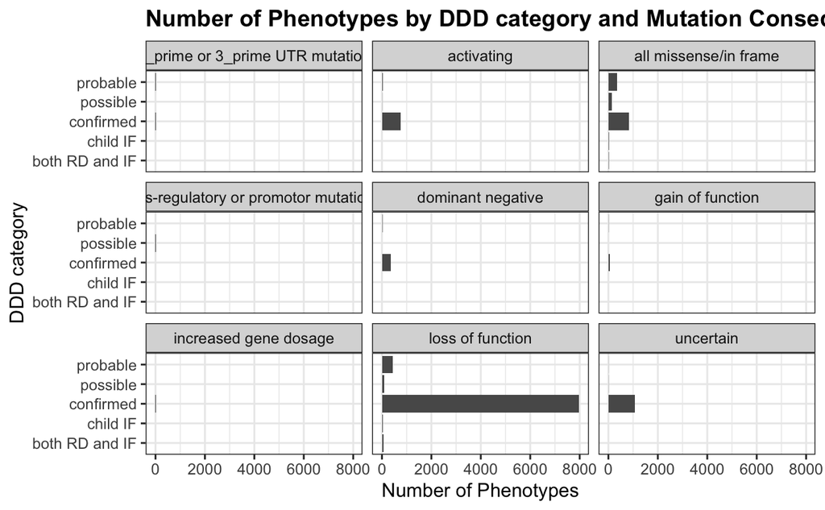

### 2.1 Mutation Consequences

1. Loss of Function

Nonsense, frame-shifting indel, essential splice site mutation, whole gene deletion or any other mutation where functional analysis demonstrates clear reduction or loss of function

2. All missense/in frame

Where all the mutations described in the data source are either missense or in frame deletions and there is no evidence favoring either loss-of-function, activating or dominant negative effect

3. Dominant negative

Mutation within one allele of a gene that creates a significantly greater deleterious effect on gene product function than a monoallelic loss of function mutation

4. Activating

Mutation, usually missense that results in a constituative functional activation of the gene product

5. Increased gene dosage

Copy number variation that increases the functional dosage of the gene

6. Cis-regulatory or promotor mutation

Mutation in cis-regulatory elements that lies outwith the known transcription unit and promotor of the controlled gene

7. Uncertain

Where the exact nature of the mutation is unclear or not recorded

## 3. Conclusion

I wanted to find out if the number of phenotypes for each disease were related to DDD categories of mutation consequences. From the plot I made, I found that the highest number of phenotypes were found in the *confirmed* DDD category of *loss of function* mutation consequences. Also, number of phenotypes were barely shown in gain of function, increased gene dosage, cis-regulatory or promotor mutation, 5_prime or 3_prime UTR mutation.